# LGC_Model

Mahlika George

12/9/2020

```r
library("lavaan")
library("readxl")
library("broom")
```

## Downloading and formatting the data

Importing the excel sheets and saving each sheet as a new variable:

```r
for (i in 1:10) {
  assign(paste0("my_data",i),read_excel("/Users/mahlikageorge/Capstone_Code/Capstone_Code_Final/Data/2007-2016.xlsx",i))
}
```

Storing the important values (indivudal clearance rates, populations, and crime rates) as variables. A new variable is created with respect to the year.

```r
#I.E: AggravatedAssault1 corresponds to the aggravated assault clearance rate column of the first year
for (i in 1:10) {
  assign(paste0("AggravatedAssault",i),eval(parse(text = paste0("my_data",i)))$`Aggravated Assault Clearance Rate`)
  assign(paste0("Rob",i),eval(parse(text = paste0("my_data",i)))$`Robbery Clearance Rate`)
  assign(paste0("Mrdr",i),eval(parse(text = paste0("my_data",i)))$`Murder/Nonnegligent Manslaughter Clearance Rate`)
  assign(paste0("Pop",i),eval(parse(text = paste0("my_data",i)))$`Total Population`)
  assign(paste0("Cr_rte",i),eval(parse(text = paste0("my_data",i)))$`Crime Rate`)
}
```

The following chunk of code stores all of the values we extracte in the preiouvs chunk into a new data frame:

```r
FinalData <- data.frame(aa1=AggravatedAssault1,robbery1=Rob1,murder1=Mrdr1,population1=Pop1,crime_rate1=Cr_rte1,
                        aa2=AggravatedAssault2,robbery2=Rob2,murder2=Mrdr2,population2=Pop2,crime_rate2=Cr_rte2,
                        aa3=AggravatedAssault3,robbery3=Rob3,murder3=Mrdr3,population3=Pop3,crime_rate3=Cr_rte3,
                        aa4=AggravatedAssault4,robbery4=Rob4,murder4=Mrdr4,population4=Pop4,crime_rate4=Cr_rte4,
                        aa5=AggravatedAssault5,robbery5=Rob5,murder5=Mrdr5,population5=Pop5,crime_rate5=Cr_rte5,
                        aa6=AggravatedAssault6,robbery6=Rob6,murder6=Mrdr6,population6=Pop6,crime_rate6=Cr_rte6,
                        aa7=AggravatedAssault7,robbery7=Rob7,murder7=Mrdr7,population7=Pop7,crime_rate7=Cr_rte7,
                        aa8=AggravatedAssault8,robbery8=Rob8,murder8=Mrdr8,population8=Pop8,crime_rate8=Cr_rte8,
                        aa9=AggravatedAssault9,robbery9=Rob9,murder9=Mrdr9,population9=Pop9,crime_rate9=Cr_rte9,
                        aa10=AggravatedAssault10,robbery10=Rob10,murder10=Mrdr10,population10=Pop10,crime_rate10=Cr_rte10

                        )
```

The following is the creation of the first model. This model is the latent growth curve model calculation for the Aggravated Assault Clearance Rates. It finds the intercept and slopes using the crime rate and population as time-varying covariates.

```r
model1 <-'
#intercept and slope with fixed coefficients

#intercept calculation
i=~ 1*aa1 + 1*aa2 + 1*aa3 + 1*aa4 + 1*aa5 + 1*aa6 + 1*aa7 + 1*aa8 + 1*aa9 + 1*aa10

#linear slope calculation
s=~ 0*aa1 + 1*aa2 + 2*aa3 + 3*aa4 + 4*aa5 + 5*aa6 + 6*aa7 + 7*aa8 + 8*aa9 + 9*aa10

#quadratic slope calculation
q=~ 0*aa1 + 1*aa2 + 4*aa3 + 9*aa4 + 16*aa5 + 25*aa6 + 36*aa7 + 49*aa8 + 64*aa9 + 81*aa10

#time-varying covariates
aa1 ~ population1 + crime_rate1
aa2 ~ population2 + crime_rate2
aa3 ~ population3 + crime_rate3
aa4 ~ population4 + crime_rate4
aa5 ~ population5 + crime_rate5
aa6 ~ population6 + crime_rate6
aa7 ~ population7 + crime_rate7
aa8 ~ population8 + crime_rate8
aa9 ~ population9 + crime_rate9
aa10 ~ population10 + crime_rate10
'
```

The following is the summary statistics of the model we just developed for the Aggravated Assault incidents:

```r
fit1 <- growth(model1,data = FinalData)
summary(fit1)
```

```
## lavaan 0.6-7 ended normally after 366 iterations
##
##   Estimator                                         ML
##   Optimization method                           NLMINB
##   Number of free parameters                         39
##
##                                                   Used       Total
##   Number of observations                            85         100
##
## Model Test User Model:
##
##   Test statistic                               285.800
##   Degrees of freedom                               226
##   P-value (Chi-square)                           0.004
##
## Parameter Estimates:
##
##   Standard errors                             Standard
##   Information                                 Expected
##   Information saturated (h1) model          Structured
##
## Latent Variables:
##                    Estimate         Std.Err  z-value  P(>|z|)
##   i =~
##     aa1                      1.000
##     aa2                      1.000
##     aa3                      1.000
##     aa4                      1.000
##     aa5                      1.000
##     aa6                      1.000
##     aa7                      1.000
##     aa8                      1.000
##     aa9                      1.000
##     aa10                     1.000
##   s =~
##     aa1                      0.000
##     aa2                      1.000
##     aa3                      2.000
##     aa4                      3.000
##     aa5                      4.000
```

[output cut: 74 more lines]

```
## Variances:
##                    Estimate         Std.Err  z-value  P(>|z|)
##    .aa1                    161.908   32.829    4.932    0.000
##    .aa2                    221.129   35.555    6.219    0.000
##    .aa3                    125.475   20.584    6.096    0.000
##    .aa4                    207.324   32.830    6.315    0.000
##    .aa5                    217.063   34.273    6.333    0.000
##    .aa6                    177.645   28.291    6.279    0.000
##    .aa7                    212.268   33.380    6.359    0.000
##    .aa8                    162.990   26.159    6.231    0.000
##    .aa9                    182.105   30.297    6.011    0.000
##    .aa10                   169.623   35.208    4.818    0.000
##     i                       -3.508   21.836   -0.161    0.872
##     s                       -2.964    5.064   -0.585    0.558
##     q                       -0.026    0.057   -0.461    0.645
```

The following is the creation of the second model. This model is the latent growth curve model calculation for the Robbery Clearance Rates. It finds the intercept and slopes using the crime rate and population as time-varying covariates.

```r
model2 <-'
#intercept and slope with fixed coefficients

#intercept calculation
i=~ 1*robbery1 + 1*robbery2 + 1*robbery3 + 1*robbery4 + 1*robbery5 + 1*robbery6 + 1*robbery7 + 1*robbery8 + 1*robbery9 + 1*robbery10

#linear slope calculation
s=~ 0*robbery1 + 1*robbery2 + 2*robbery3 + 3*robbery4 + 4*robbery5 + 5*robbery6 + 6*robbery7 + 7*robbery8 + 8*robbery9 + 9*robbery10

#quadratic slope calculation
q=~ 0*robbery1 + 1*robbery2 + 4*robbery3 + 9*robbery4 + 16*robbery5 + 25*robbery6 + 36*robbery7 + 49*robbery8 + 64*robbery9 + 81*robbery10

#time-varying covariates
robbery1 ~ population1 + crime_rate1
robbery2 ~ population2 + crime_rate2
robbery3 ~ population3 + crime_rate3
robbery4 ~ population4 + crime_rate4
robbery5 ~ population5 + crime_rate5
robbery6 ~ population6 + crime_rate6
robbery7 ~ population7 + crime_rate7
robbery8 ~ population8 + crime_rate8
robbery9 ~ population9 + crime_rate9
robbery10 ~ population10 + crime_rate10
'
```

The following is the summary statistics of the model we just developed for the Robbery incidents:

```r
fit2 <- growth(model2,data = FinalData)
summary(fit2)
```

```
## lavaan 0.6-7 did NOT end normally after 598 iterations
## ** WARNING ** Estimates below are most likely unreliable
##
##   Estimator                                         ML
##   Optimization method                           NLMINB
##   Number of free parameters                         39
##
##                                                   Used       Total
##   Number of observations                            69         100
##
## Model Test User Model:
##
##   Test statistic                                    NA
##   Degrees of freedom                                NA
##
## Parameter Estimates:
##
##   Standard errors                             Standard
##   Information                                 Expected
##   Information saturated (h1) model          Structured
##
## Latent Variables:
##                    Estimate         Std.Err  z-value  P(>|z|)
##   i =~
##     robbery1                 1.000
##     robbery2                 1.000
##     robbery3                 1.000
##     robbery4                 1.000
##     robbery5                 1.000
##     robbery6                 1.000
##     robbery7                 1.000
##     robbery8                 1.000
##     robbery9                 1.000
##     robbery10                1.000
##   s =~
##     robbery1                 0.000
##     robbery2                 1.000
##     robbery3                 2.000
##     robbery4                 3.000
##     robbery5                 4.000
```

[output cut: 74 more lines]

```
## Variances:
##                    Estimate         Std.Err  z-value  P(>|z|)
##    .robbery1                52.199       NA
##    .robbery2                84.530       NA
##    .robbery3                54.849       NA
##    .robbery4               122.155       NA
##    .robbery5                81.191       NA
##    .robbery6                51.743       NA
##    .robbery7               139.428       NA
##    .robbery8                92.570       NA
##    .robbery9                81.231       NA
##    .robbery10               84.464       NA
##     i                        4.521       NA
##     s                        5.636       NA
##     q                        0.085       NA
```

The following stores all of the coefficients we found in the previous modelings:

```r
i1 = coef(fit1)[37] #aggravated assault intercept
s1 = coef(fit1)[38] #aggravated assault linear slope
q1 = coef(fit1)[39] #aggravated assault quadratic slope

i2 = coef(fit2)[37] #robbery intercept
s2 = coef(fit2)[38] #robbery linear slope
q2 = coef(fit2)[39] #robbery quadratic slope
```

The following is the plot created from the intercepts and slopes we previously found:

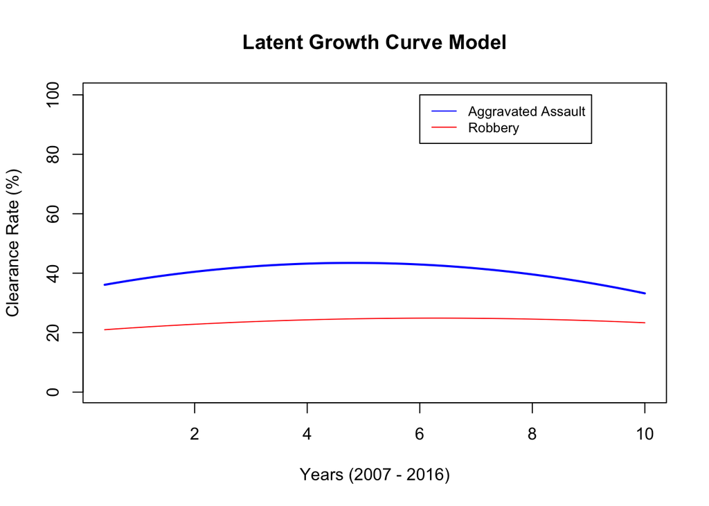

```r
plot.new()
eq = "Latent Growth Curve Model" #Title

#Aggravated Assault Equation
curve(main = eq,q1 * x^2 + s1 * x + i1, xlim = c(0.4,10), ylim = c(0.4,100), lwd = 2,xlab="Years (2007 - 2016)", ylab="Clearance Rate (%)",col='blue')

#Robbery Equation
curve(q2 * x^2 + s2 * x + i2, add = TRUE, col = "red")

#The creation of the legend
legend(6, 100, legend=c("Aggravated Assault", "Robbery"),
       col=c("blue", "red"), lty=1, cex=0.8)
```